# levantamento topografico

### GIT GIT GIT

Git é um sistema de backup baseado em comparação de versões. Seu pleno potencial é alcançado quando utilizado em combinação com o http://github.com.

Este projeto inteiro tem uma imagem espelhada no endereço http://github.com/cassianogatto/memorial_descritivo e esta versão *online* oferece a possibilidade de rodar o **app Dabukuri** de qualquer computador com o programa R instalado. Melhor ainda se [RStudio](https://posit.co/download/rstudio-desktop) estiver instalado porque ele cuida automaticamente das dependências, libraries, etc.

No console do RStudio, basta digitar:

```
library(shiny)
runGitHub( "cassianogatto/memorial_descritivo/Dabukuri_espacial", "cassianogatto")
```

#### Espelho de diretório local

Esta página é um backup que deve ser sempre atualizado. Todas as versões anteriores podem ser recuperadas, mas estas propriedades avançadas não serão discutidas aqui.

Pra começar é preciso identificar o diretório no computador que corresponde exatamente ao diretório github. Neste projeto o diretório é:

```
C:/Users/Cliente/Documents/Cassiano/Shiny/Memorial_markdown-shiny/Memorial_descritivo
```

Após abrir no explorer, clicar com botão direito e escolher ‘git bash’ (figura 1)

[figure not shown]

figura 1. Abrindo GIT BASH

Agora digitaremos comandos que sempre iniciam com **‘git’**!

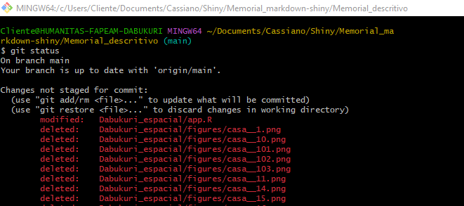

figura 2. GIT status

Para começar a sincronização deve-se adicionar estes arquivos ao ‘stage’ (palco). Para adicionar todos basta digitar ‘git add .’ (figura 3; para adicionar um à um ‘git add ’).

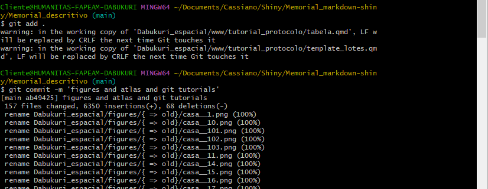

figura 3. GIT add